# ML_1

Wong Yat Chun

2017 M12 23

Import Library

```r
library(ggplot2) #visualizations
library(plyr) #data manipulation
library(scales) #fix date formats in plots
```

Import data file

```r
ufo <- read.delim(file.path("data","ufo","ufo_awesome.tsv"),#tab-delimited file, use 'read.delim' and set the separator
                  sep = "\t",
                  stringsAsFactors = FALSE, #we don't want the strings to be converted to factor types
                  #It is always a good practice to switch off this default
                  header = F, #since this data does not have header labels in the first row
                  na.strings = "") #there are many empty elements in the data, and we want to set those to the special R value NA
```

Inspect the data frame

```r
summary(ufo)
```

```
##       V1                 V2                 V3
##  Length:61870       Length:61870       Length:61870
##  Class :character   Class :character   Class :character
##  Mode  :character   Mode  :character   Mode  :character
##       V4                 V5                 V6
##  Length:61870       Length:61870       Length:61870
##  Class :character   Class :character   Class :character
##  Mode  :character   Mode  :character   Mode  :character
```

```r
head(ufo)
```

```
##         V1       V2                    V3   V4      V5
## 1 19951009 19951009         Iowa City, IA <NA>    <NA>
## 2 19951010 19951011         Milwaukee, WI <NA>  2 min.
## 3 19950101 19950103           Shelton, WA <NA>    <NA>
## 4 19950510 19950510          Columbia, MO <NA>  2 min.
## 5 19950611 19950614           Seattle, WA <NA>    <NA>
## 6 19951025 19951024  Brunswick County, ND <NA> 30 min.
##                                                                                                                                                                                        V6
## 1                                          Man repts. witnessing &quot;flash, followed by a classic UFO, w/ a tailfin at back.&quot; Red color on top half of tailfin. Became triangular.
## 2                                                       Man  on Hwy 43 SW of Milwaukee sees large, bright blue light streak by his car, descend, turn, cross road ahead, strobe. Bizarre!
## 3 Telephoned Report:CA woman visiting daughter witness discs and triangular ships over Squaxin Island in Puget Sound. Dramatic.  Written report, with illustrations, submitted to NUFORC.
## 4                                                    Man repts. son&apos;s bizarre sighting of small humanoid creature in back yard.  Reptd. in Acteon Journal, St. Louis UFO newsletter.
## 5                                                            Anonymous caller repts. sighting 4 ufo&apos;s in NNE sky, 45 deg. above horizon.  (No other facts reptd.  No return tel. #.)
## 6                                                      Sheriff&apos;s office calls to rept. that deputy, 20 mi. SSE of Wilmington,  is looking at peculiar, bright white, strobing light.
```

Set the meaningful column names using the ‘names’ function

```r
names(ufo) <- c("DateOccurred","DateReported",
                "Location","ShortDescription",
                "Duration","LongDescription")
```

Convert the Date string to an R Date type using the ‘strptime’ function However, if we use

```r
#ufo$DateOccurred <-as.Date(ufo$DateOccurred,format="%Y%m%d")
```

we will see Error in strptime(x,format,tz=“GMT”):input string is too long It indicates that some of the entries in the DateOccurred column are too long to match the format string we provided, perhaps some of the data was malformed in the original set.

We will just ignore the errata by removing those entries that have not parsed correctly. We know that the date strings are always 8 characters long, and any deviation from this would indicate a row to ignore. We will use the ‘ifelse’ function ton construct a vector of Booleans indicating the problem rows

```r
good.rows <- ifelse(nchar(ufo$DateOccurred)!=8|
                      nchar(ufo$DateReported)!=8,
                    FALSE,
                    TRUE)
ufo <- ufo[good.rows,]
ufo$DateOccurred <- as.Date(ufo$DateOccurred,format = "%Y%m%d")
ufo$DateReported <- as.Date(ufo$DateReported,format = "%Y%m%d")
```

Create separate columns for both town and state from the location column. To do so we will use the ‘strsplit’ function to perform the regex. Note: not every entry in Location is of the form ‘City, State’. We use the ‘tryCatch’ function to simply return [NA,NA] when this is the case. Next, we remove the leading white-space from both the city and state strings with ‘gsub’

```r
get.location <- function(l){
  split.location <- tryCatch(strsplit(l,",")[[1]],
                             error=function(e) return(c(NA,NA)))
  clean.location <- gsub("^ ","",split.location)
  if(length(clean.location)>2){
    return(c(NA,NA))
  }else{
    return(clean.location)
  }
}
#we use 'lapply' to return a list with [City,State] vector as each element
city.state <- lapply(ufo$Location,get.location)
#we use 'do.call' to collapse the list to an N-by-2 matrix
location.matrix <- do.call(rbind,city.state)
#do.call executes a function call over a list.
ufo <- transform(ufo,
                 USCity=location.matrix[,1],
                 USState=tolower(location.matrix[,2]),
                 stringsAsFactor=FALSE)
# Next step, we will strip out non-US incidents

# Insert NA's where there are non-US cities
us.states<-c("ak","al","ar","az","ca","co","ct","de","fl","ga","hi","ia","id","il",
"in","ks","ky","la","ma","md","me","mi","mn","mo","ms","mt","nc","nd","ne","nh",
"nj","nm","nv","ny","oh","ok","or","pa","ri","sc","sd","tn","tx","ut","va","vt",
"wa","wi","wv","wy")
ufo$USState<-us.states[match(ufo$USState,us.states)]
ufo$USCity[is.na(ufo$USState)]<-NA
# Finally, we'll use 'subset' to examine only events in the United States and convert
# states to factors, i.e., a categorical variable.
ufo.us<-subset(ufo, !is.na(USState))
```

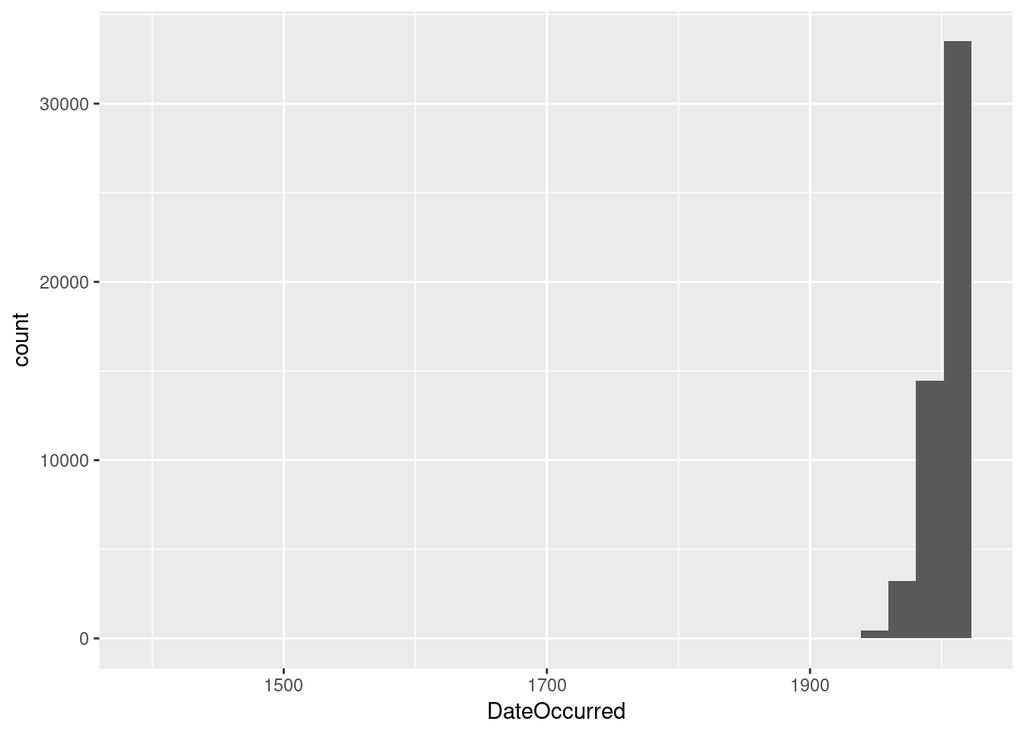

```r
ggplot(ufo.us, aes(DateOccurred)) +
  geom_histogram()
```

First, we notice that there are many very old entries in the data. For our purposes, we will only look at incidents that occurred from 1990 to the most recent

```r
ufo.us <- subset(ufo.us, DateOccurred >= as.Date("1990-01-01"))
```

Let’s look at the histogram now

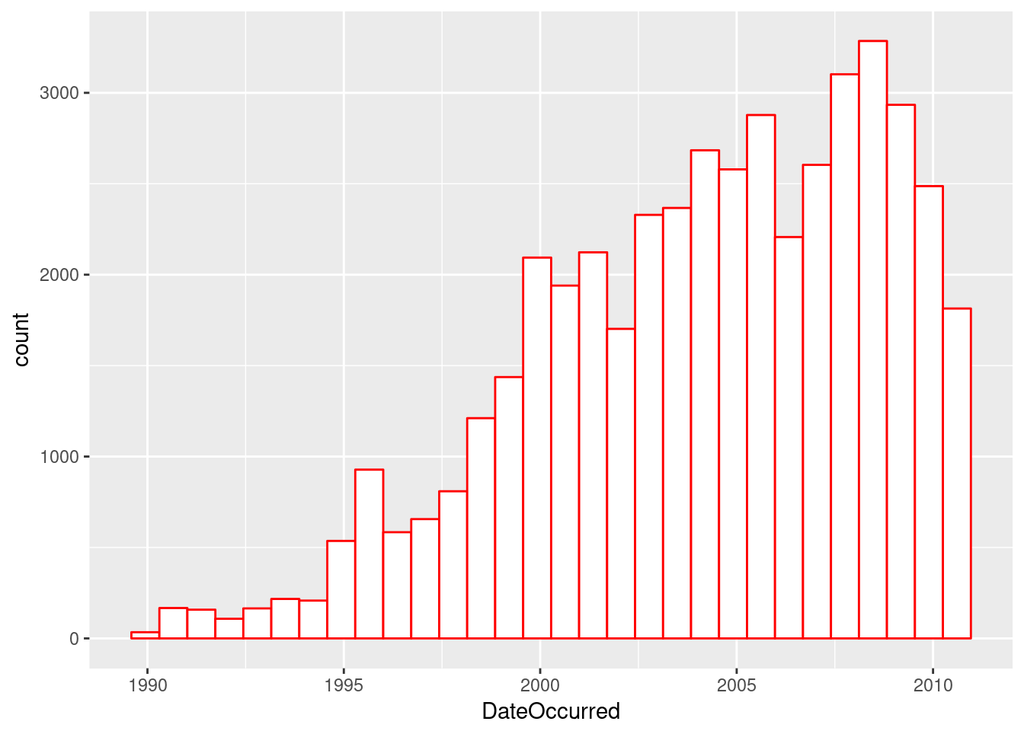

```r
new.hist <- ggplot(ufo.us, aes(x = DateOccurred)) +
  geom_histogram(aes(fill='white', color='red')) +
  scale_fill_manual(values=c('white'='white'), guide="none") +
  scale_color_manual(values=c('red'='red'), guide="none")
new.hist
```

Now that we have the data we want, let’s look at some aggregations. We will use the ‘ddply’ funtion in the plyr package. But first, we create a column of just the Year-Month of each incident.

```r
ufo.us$YearMonth <- strftime(ufo.us$DateOccurred, format = "%Y-%m")
```

This will return the number of sightings of UFO by Year-Month and state for the whole time-series

```r
sightings.counts <- ddply(ufo.us, .(USState,YearMonth), nrow)
```

As we might expect, there are several Year-Month and state combinations for which there are no UFO sightings. We need to count these as zero so we can go back and fill those in. First, we will create a new vector that has all of the Year-Month dates in it that span the range of our time-series (1990-2010)

```r
date.range <- seq.Date(from = as.Date(min(ufo.us$DateOccurred)),
                       to = as.Date(max(ufo.us$DateOccurred)),
                       by = "month")
date.strings <- strftime(date.range, "%Y-%m")
```

To fill in the missing dates from the ‘sightings.counts’ data frame we will need to create a separate data frame with a column of states and Year-Months.

```r
states.dates <- lapply(us.states, function(s) cbind(s, date.strings))
states.dates <- data.frame(do.call(rbind, states.dates),
                           stringsAsFactors = FALSE)
```

We use ‘merge’ to take the counts we have and merge them with the missing dates. Note, we have to specify the columns from each data frame we are using to do the merge, and set ‘all’ to TRUE, which will fill in this missing dates from the original data frame with NA.

```r
all.sightings <- merge(states.dates,
                       sightings.counts,
                       by.x = c("s", "date.strings"),
                       by.y = c("USState", "YearMonth"),
                       all = TRUE)
```

Now we just need to clean up the merged data frame a bit Set the column names to something meaningful

Covert the NAs to 0’s, what we really wanted Reset the character Year-Month to a Date objects Capitalize the State abbreviation and set as factor

```r
names(all.sightings) <- c("State", "YearMonth", "Sightings")
all.sightings$Sightings[is.na(all.sightings$Sightings)] <- 0
all.sightings$YearMonth <- as.Date(rep(date.range, length(us.states)))
all.sightings$State <- as.factor(all.sightings$State)
```

test the seasonality of of these sightings, one basic method is to inspect the trends visually. We now construct a plot that will show these trends for all 50 U.S. states over the time-series.

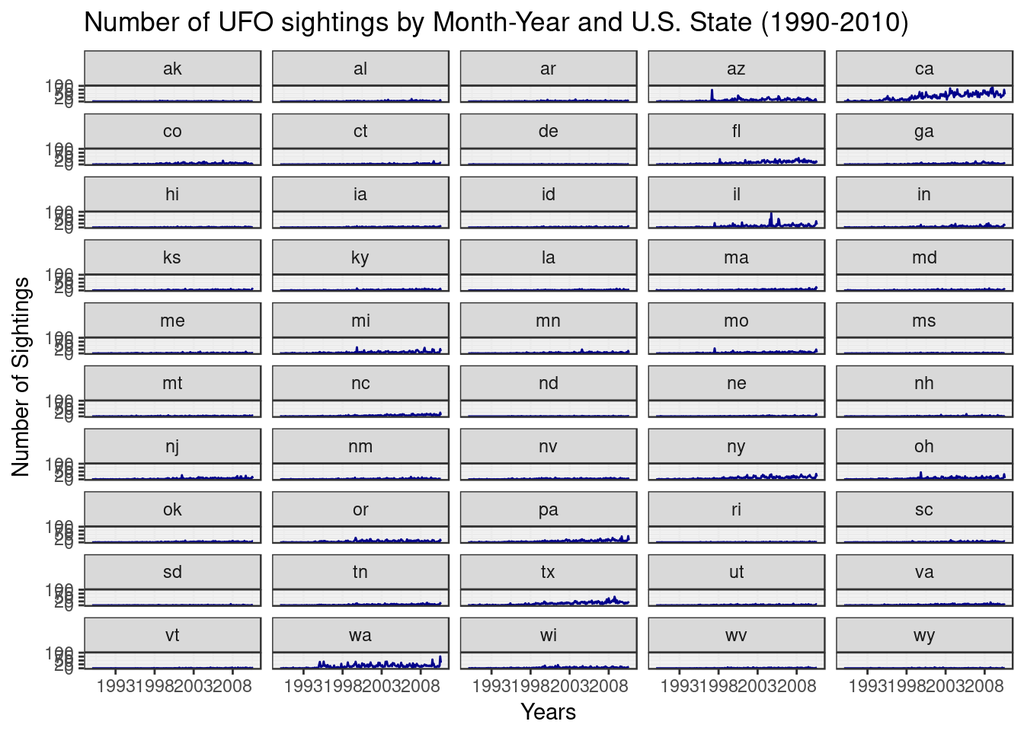

```r
state.plot <- ggplot(all.sightings, aes(x = YearMonth,y = Sightings)) +
  geom_line(aes(color = "darkblue")) +
  facet_wrap(~State, nrow = 10, ncol = 5) +
  theme_bw() +
  scale_color_manual(values = c("darkblue" = "darkblue"), guide = "none") +
  scale_x_date(date_breaks = "5 years", labels = date_format('%Y')) +
  xlab("Years") +
  ylab("Number of Sightings") +
  ggtitle("Number of UFO sightings by Month-Year and U.S. State (1990-2010)")
state.plot
```

Create a new graph where the number of signtings is normailzed by the state population

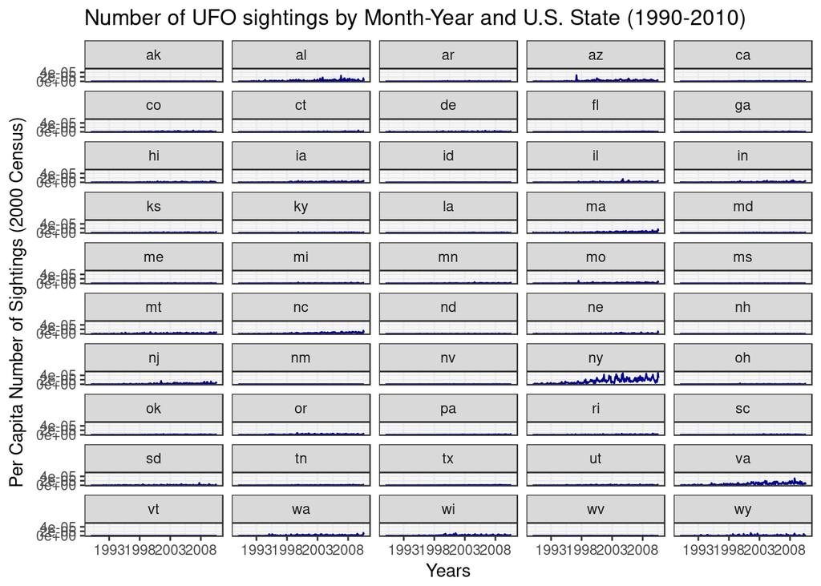

```r
state.pop <- read.csv(file.path('data/census.csv'),
                      stringsAsFactors=FALSE)

state.pop$abbs <- sapply(state.pop$State,
                         function(x) us.states[grep(paste('^', x, sep=''), state.name)])
all.sightings$Sightings.Norm <- sapply(1:nrow(all.sightings),
    function(i) all.sightings$Sightings[i] / state.pop$X2000[which(state.pop$abbs== all.sightings$State[i])])


state.plot.norm <- ggplot(all.sightings, aes(x = YearMonth,y = Sightings.Norm)) +
  geom_line(aes(color = "darkblue")) +
  facet_wrap(~State, nrow = 10, ncol = 5) +
  theme_bw() +
  scale_color_manual(values = c("darkblue" = "darkblue"), guide = "none") +
  scale_x_date(date_breaks = "5 years", labels = date_format('%Y')) +
  xlab("Years") +
  ylab("Per Capita Number of Sightings (2000 Census)") +
  ggtitle("Number of UFO sightings by Month-Year and U.S. State (1990-2010)")

state.plot.norm
```